# The response of supplements on Tooth Growth of Guinea Pigs

Sayef Ishauqe

October 09, 2017

### Overview

This papaer analyzes the Tooth Growth data available in R datasets to infer the response of supplements on tooth growth from the sample. The analyis will evaluate hypothesises across delivery methods (Orange Juice - OJ, ascrobic acid - VC) and dose levels (0.5,1,2 mg/day).

### Data Processing & Analysis

- Step 1: Load the data and examine the structure

```
##       len                               supp     dose
##  Min.   : 4.20   Orange Juice             :30   0.5:20
##  1st Qu.:13.07   Ascrobic Acid (Vitamin C):30   1  :20
##  Median :19.25                                  2  :20
##  Mean   :18.81
##  3rd Qu.:25.27
##  Max.   :33.90
```

- Step 2: Plot a bar chart of average tooth growth for different supplements and dose levels

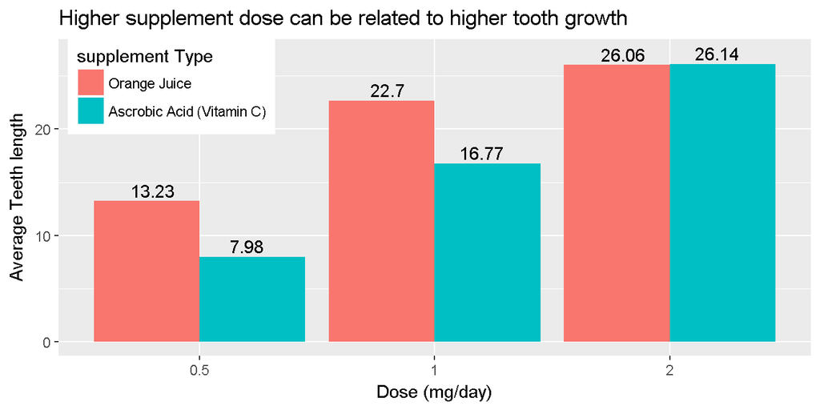

**Findings - Higher average teeth lenght is observed for higher doses.**

    *The experiment was run on 60 pigs with different dose levels and supplements.* *Same pig was not administered with different dose levels for this expericemnt* *So, its not a paired sample. However, the population variance of pig tooth* *lenght can be assumed to be identical*

```r
tDataDose12<-tData[tData$dose!=1.0,]
tres<-t.test(len~dose,data=tDataDose12,paired=F,var.equal=T)
```

**Findings - The null hypothesis (H0) can be rejected as p-value(2.837553210^{-14}) is very small**

- Step 4: Conduct a power t-test between 2 and 1 mg/day and 1 and .5 mg/day

```r
pt1<-power.t.test(n=20, delta = meanD2-meanD1, sd = sqrt((sdD2^2+sdD1^2)/2),
             sig.level = 0.05,
             type = "two.sample",
             alternative = "one.sided")

pt2<-power.t.test(n=20, delta = meanD1-meanD.5, sd = sqrt((sdD.5^2+sdD1^2)/2),
             sig.level = 0.05,
             type = "two.sample",
             alternative = "one.sided")
pt2
```

```
##
##      Two-sample t test power calculation
##
##               n = 20
##           delta = 9.13
##              sd = 4.457799
##       sig.level = 0.05
##           power = 0.9999988
##     alternative = one.sided
##
## NOTE: n is number in *each* group
```

**Findings - The sample data provide enough (high power: 0.9992,1)** **evidence to support the hypothesises** **that higher doses of supplements can be related to higher tooth growth**

- Step 5: Perform t-tests to validate the hypothesis that supplements are related to different tooth growth
  - H0-With similar dose levels, different supplements are not related to different tooth growth
  - H1- Orange Juice (OJ) is a better supplement related with tooth growth
    - Conduct T-test between supplements

```r
tres<-t.test(len~supp,data=tData,paired=F,var.equal=T)
```

*Findings - The hypothesis (H0) that different supplements does not produce* *different result (difference in mean) - can not be rejected(p-value 0.06)*

- Step 6:Conduct a power test to evaluate the number of samples required to evaluate which supplement is better

```
##
##      Two-sample t test power calculation
##
##               n = 70.72436
##           delta = 3.7
##              sd = 7.482001
##       sig.level = 0.05
##           power = 0.9
##     alternative = one.sided
##
## NOTE: n is number in *each* group
```

*At least 71 (meaning total 142) pigs has to administered with alternative supplements* *to conclude whether Orange Juice (Supp-OJ) is better supplement than Ascrobic Acid* *(Supp-VC) for tooth growth*

### Conclusion

supplements are related to higher tooth growth of pigs. However, the sample size is not large enough to conclude which supplement is more effective.